# Lecture 05: Probability and Statistical Inference

Author

Bill Perry

# **Lecture 4: Review**

- Introduction to histograms or frequency distributions
- Probability Distribution Functions (PDF)
  - Z scores and T scores
- Tests of means using T-Tests
  - one sample
  - two sample

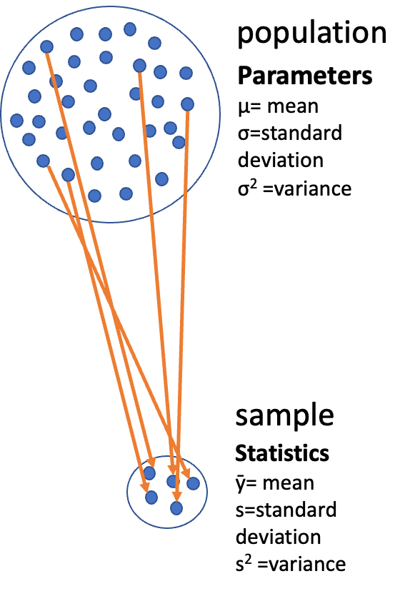

- Tests of means using T-Tests
  - one sample - is the sample mean different from a hypothesized mean?
  - two sample - are the sample means from two samples the same or different?
- for Two sample T-tests the df = n1+ n2 -2 = 8+8-2=14

```
# A tibble: 2 × 5
  side  mean_length sd_length se_length count
  <chr>       <dbl>     <dbl>     <dbl> <int>
1 shady        17.6      2.51     0.886     8
2 sunny        16.2      2.64     0.934     8
```

# **Lecture 5: Probability and Statistical Inference**

### **The goals for today**

- Statistical inference fundamentals
- Hypothesis testing principles
- T Distributions
- One sample T Test
- Two sample T Test
- Paired T Test
- Assumption tests

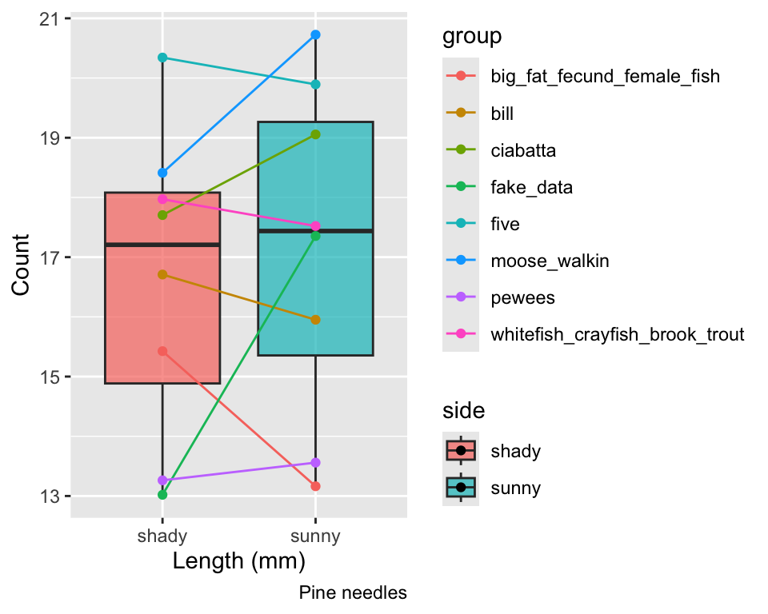

# **Lecture 5: Probability and Statistical Inference**

The goals for today

- Statistical inference fundamentals
- Hypothesis testing principles
- T Distributions
- One sample T Test
- Two sample T Test
- Paired T Test

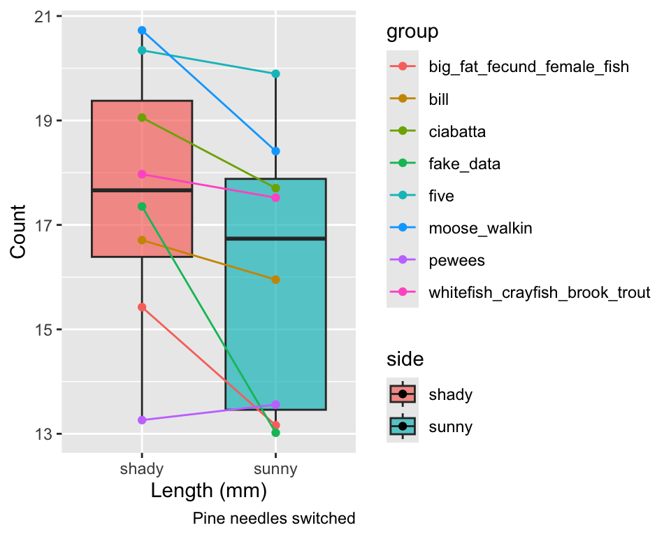

# **Lecture 5:** One-tailed Questions

One-tailed questions: area of distribution left or (right) of a certain value for a one sample test

- n=8 (df=7) - 95% of the observations found left
- t= 1.895 (5% are outside)

[figure not shown]

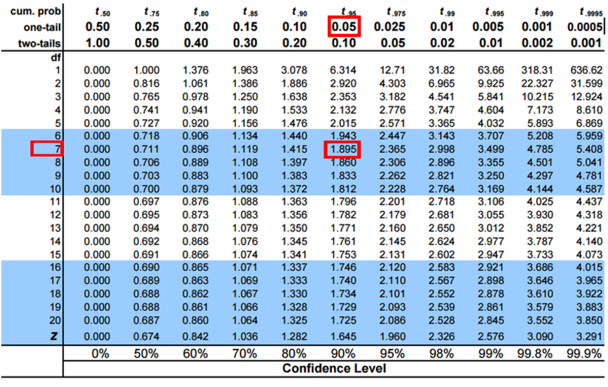

# **Lecture 5:** Two-tailed Questions

Two-tailed questions refer to area between certain values

- n= 8 (df=7), 95% of the observations are between
- t=-2.365 and t=2.365 (2.5% are outside on each side)
- One tailed was t= 1.895 (5% are outside)

[figure not shown]

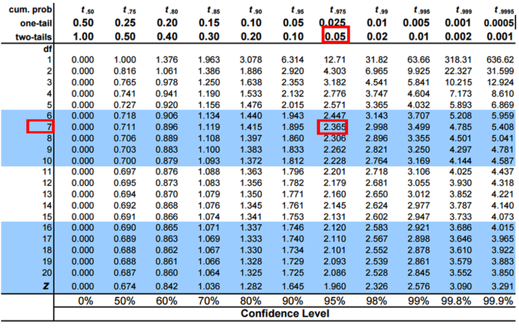

# **Lecture 5:** Calculating CI Example

Let’s calculate CIs again:

Use two-sided test

- $\text{CI} = \bar{y} \pm t \cdot \frac{s}{\sqrt{n}}$
- 95% CI Sample A: = 17.6 ± 2.365 * (2.51/(8^0.5)) = +/- 2.098746
- The 95% CI is between 15.50 and 19.70
- “The 95% CI for the population mean from sample A is 17.6 ± 2.1

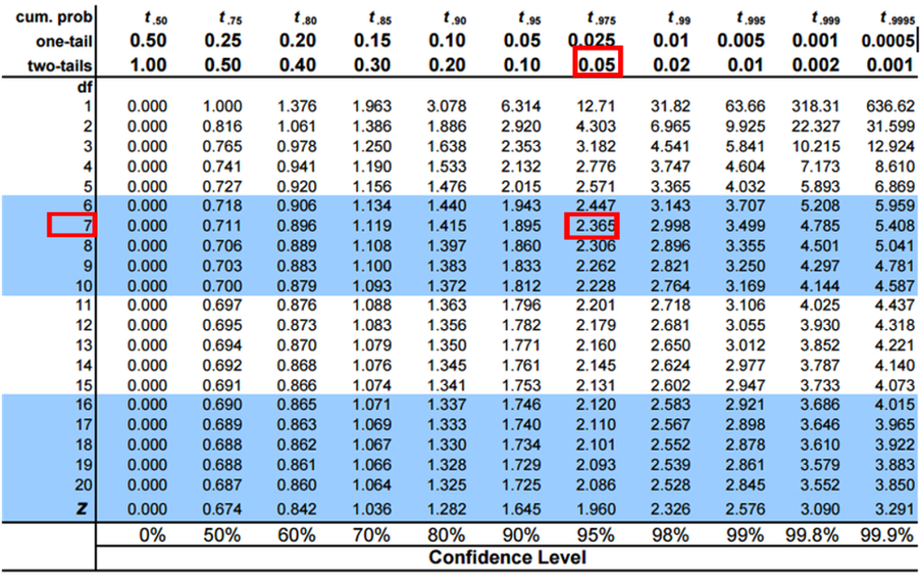

# **Lecture 5:** Applications of t-distribution

So:

- Can assess confidence that population mean is within a certain range
- Can use t distribution to ask questions like:
  - “What is probability of getting sample with mean = ȳ  
    from population with mean = µ?” (1 sample t-test)
  - “What is the probability that two samples came from  
    the same population?” (2 sample t-test)

# **Lecture 5:** One Sample T-Test

We want to test if the mean needle length on one side differs from 15mm.

### **Activity: Define hypotheses and identify assumptions**

H₀: μ = 15 (The mean needle length on shade side is 15mm)

### Assumptions for t-test:

1. Data is normally distributed
2. Observations are independent
3. No significant outliers

# Assumptions in R - qqplots from car

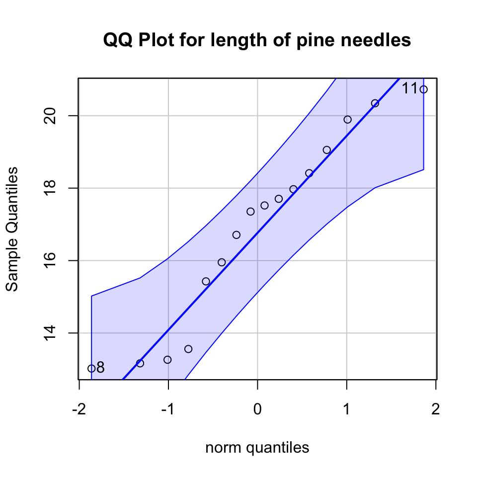

```
[1]  8 11
```

```r
# YOUR TASK: Test normality of all pine needle lengths
# QQ Plot
qqPlot(ps_df$length_mm,
       main = "QQ Plot for length of pine needles",
       ylab = "Sample Quantiles")
```

# Statistical Test of Normality

### Shapiro-Wilk test

```r
# Shapiro-Wilk test
shapiro.test(ps_df$length_mm)
```

```
    Shapiro-Wilk normality test

data:  ps_df$length_mm
W = 0.92754, p-value = 0.2228
```

# Checking for Outliers

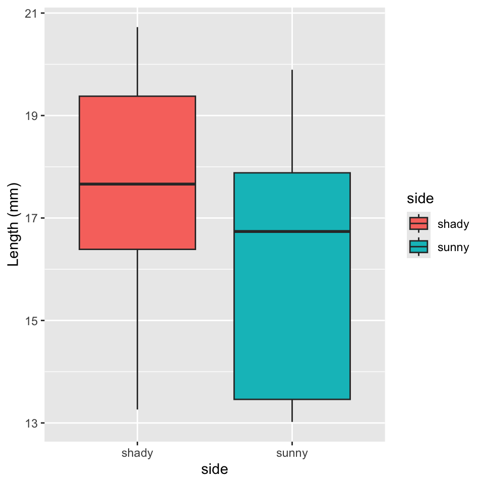

```r
# Check for outliers using boxplot
# YOUR CODE HERE
# Create a boxplot comparing the two lakes
shady_sunny_plot <- ps_df %>%
  ggplot(aes(x = side, y = length_mm, fill = side)) +
  geom_boxplot() +
  labs(
       x = "side",
       y = "Length (mm)",
       fill = "side")
shady_sunny_plot
```

# Practice Exercise 1: One-Sample t-Test

**Practice Exercise 1: One-Sample t-Test**

Let’s perform a one-sample t-test to determine if the mean needle length on the shady side differs from 15 mm:

```r
# what is the mean
ps_shade_mean <- mean(ps_shady_df$length_mm, na.rm = TRUE)
cat("Mean:", round(ps_shade_mean, 1), "mm\n")
```

```
Mean: 17.6 mm
```

```r
# Perform a one-sample t-test
t_test_result <- t.test(ps_shady_df$length_mm, mu = 15)
t_test_result
```

```
    One Sample t-test

data:  ps_shady_df$length_mm
t = 2.9414, df = 7, p-value = 0.02167
alternative hypothesis: true mean is not equal to 15
95 percent confidence interval:
 15.51092 19.70030
sample estimates:
mean of x
 17.60561
```

Interpret this test result by answering these questions:

1. What was the null hypothesis?
2. What was the alternative hypothesis?
3. What does the p-value tell us?
4. Should we reject or fail to reject the null hypothesis at α = 0.05?
5. What is the practical interpretation of this result for botanists?

# **Lecture 5:** Hypothesis Testing Framework

Hypothesis testing is a systematic way to evaluate research questions using data.

**Key components:**

1. **Null hypothesis (Ho)**: Typically assumes “no effect” or “no difference”
2. **Alternative hypothesis (Ha)**: The claim we’re trying to support
3. **Statistical test**: Method for evaluating evidence against H₀
4. **P-value**: Probability of observing our results (or more extreme) if H₀ is true
5. **Significance level (α)**: Threshold for rejecting H₀, typically 0.05

**Decision rule**: Reject Ho if p-value less than α or shorthand p < 0.05

[figure not shown]

# **Lecture 5:** Hypothesis Testing

Hypothesis testing is a systematic way to evaluate research questions using data.

**Key components:**

1. **Null hypothesis (H₀)**: Typically assumes “no effect” or “no difference”
2. **Alternative hypothesis (Hₐ)**: The claim we’re trying to support
3. **Statistical test**: Method for evaluating evidence against H₀
4. **P-value**: Probability of observing our results (or more extreme) if H₀ is true
5. **Significance level (α)**: Threshold for rejecting H₀, typically 0.05

**Decision rule**: Reject H₀ if p-value < α

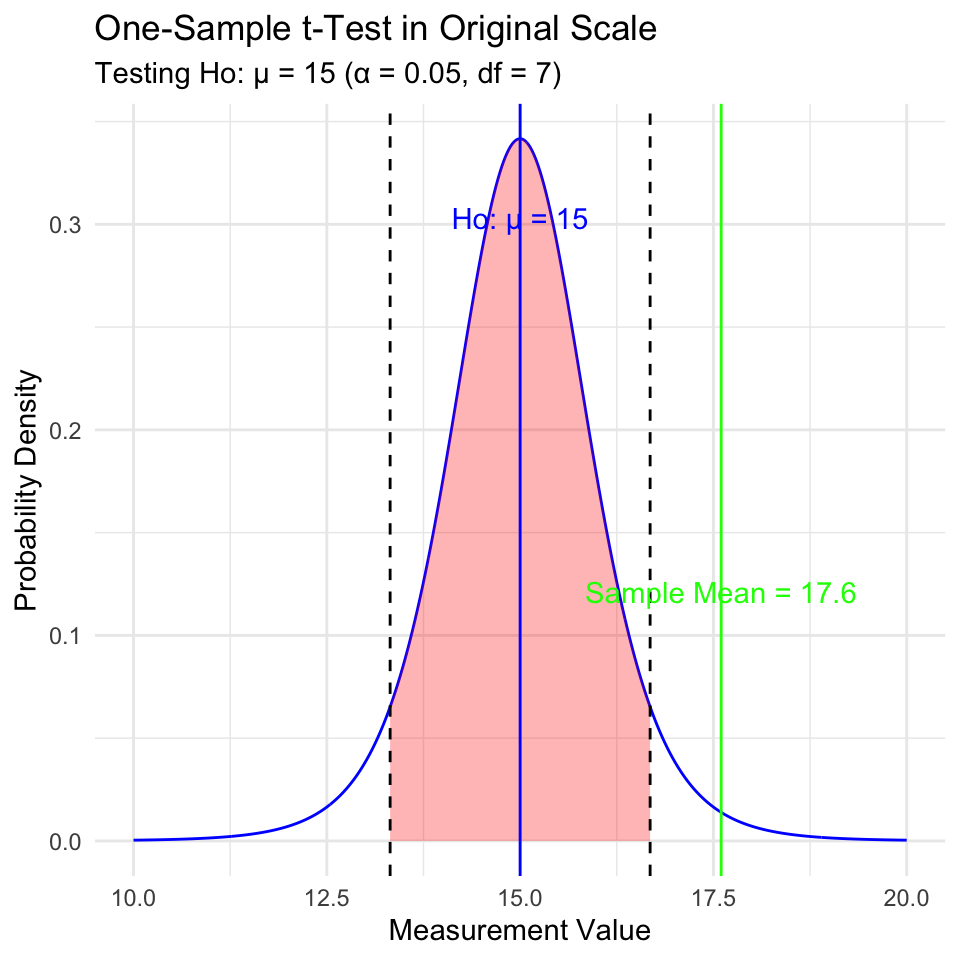

# Lecture 5: Interpreting One-Sample T-Test Results

**Activity: Interpret the t-test results**

- What does the p-value tell us?
- Should we reject or fail to reject the null hypothesis?

**How to report this result in a scientific paper:**

“A one-sample t-test at α=0.05 showed that the mean needle length (… mm, SD = …) [was/was not] significantly different from the expected 15 mm, t(…) = …, p = …”

# **Lecture 5:** Two Sample T-Tests Introduction

For example

- what is probability that population X is the same as population Y?
- How would you assess this question using what we learned?
- This is what we will do with the needle length again…

[figure not shown]

# **Lecture 5:** Comparing Two Samples

For example

- what is probability that population X is the same as population Y?

How would you assess this question using what we learned?

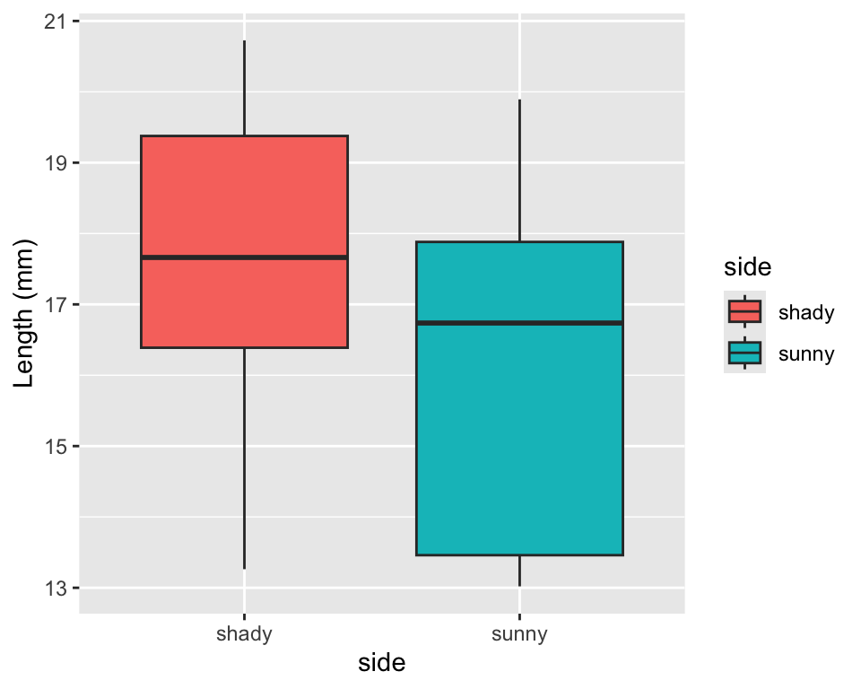

```r
shady_sunny_plot
```

```r
# Based on the t-test results and the boxplot
#
# what can you conclude about the needle lenght on the two sides?
```

# Practice Exercise 2: Formulating Hypotheses

**Practice Exercise 2: Formulating Hypotheses**

For the following research questions about needle lengths write the null and alternative hypotheses:

1. Are needle lengths on shady and sunny sides different?

What are the hypotheses?

Ho =

Ha =

# **Lecture 5:** Two-Sample T-Test Framework

Now, let’s compare needles lengths from the two sides

Question: **Is there a significant difference in needle length between the sides?**

This requires a two-sample t-test.

Two-sample t-test compares means from two independent groups.

### $t = \frac{\bar{x}_1 - \bar{x}_2}{S_p\sqrt{\frac{1}{n_1} + \frac{1}{n_2}}}$

### where:

- x̄₁ and x̄₂: These represent the sample means of the two groups you’re comparing
- s²ₚ: This is the pooled variance, calculated as: s²ₚ = [(n₁ - 1)s₁² + (n₂ - 1)s₂²] / (n₁ + n₂ - 2), where s₁² and s₂² are the sample variances of the two groups.
- **n₁ and n₂:** These are the sample sizes of the two groups.
- **√(1/n₁ + 1/n₂):** This represents the pooled standard error.

### $t = \frac{SIGNAL}{NOISE}$

# Practice Exercise 3: Summary Statistics

Before conducting the test, we need to understand the data for each group.

1. You need this and the graph to see what is going on ….

   ```r
   group_summary <- ps_df %>%
     group_by(side) %>%
     summarize(
       mean_length = mean(length_mm),
       sd_length = sd(length_mm),
       n = n(),
       se_length = sd_length / sqrt(n)
     )
   group_summary
   ```

   ```
   # A tibble: 2 × 5
     side  mean_length sd_length     n se_length
     <chr>       <dbl>     <dbl> <int>     <dbl>
   1 shady        17.6      2.51     8     0.886
   2 sunny        16.2      2.64     8     0.934
   ```

# Practice Exercise 4: Effect Size

**Practice Exercise 4: Effect size**

We could also look at the difference in means… some cool code here

```r
# Assuming your dataframe is called df
group_summary %>%
  summarize(difference = mean_length[side == "shady"] - mean_length[side == "sunny"])
```

```
# A tibble: 1 × 1
  difference
       <dbl>
1       1.45
```

# Practice Exercise 5: ggplot Summary Statistics

**Practice Exercise 5: Using GGPLOT to get summary plot**

GGplot also has code to make the mean and standard error plots we are interested in along with a lot of others

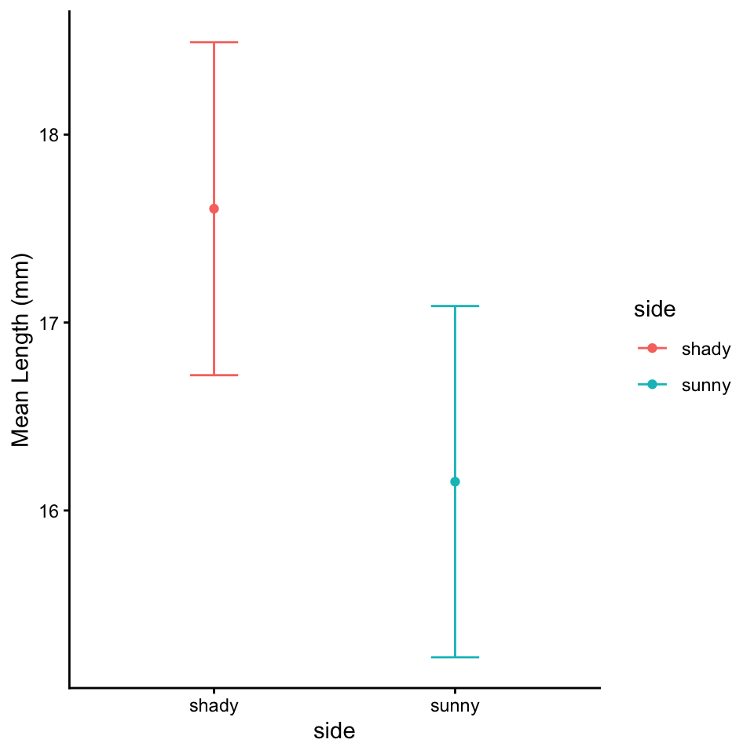

```r
# Assuming your dataframe is called df
needle_mean_se_plot <- ggplot(ps_df, aes(x = side, y = length_mm, color = side)) +
  stat_summary(fun = mean, geom = "point") +
  stat_summary(fun.data = mean_se, geom = "errorbar", width = 0.2) +
  labs(
       x = "side",
       y = "Mean Length (mm)") +
  theme_classic()
needle_mean_se_plot
```

# **Lecture 5:** Testing Assumptions for Two-Sample T-Test

For a two-sample t-test, we need to check:

1. Normality within each group
2. Equal variances between groups (for standard t-test)
3. Independent observations

If assumptions are violated:

- Welch’s t-test (unequal variances)
- Non-parametric alternatives (Mann-Whitney U test)

# Practice Exercise 6: Separate Group Data

**Practice Exercise 7: Test normality of sunny pine needle lengths**

Note you need to test each groups separately…

```r
# how do you make separate dataframes to do this on?
# Separate data by groups
head(ps_shady_df)
```

```
# A tibble: 6 × 5
# Groups:   group, tree_no, tree_char [6]
  group                      tree_no tree_char side  length_mm
  <chr>                        <dbl> <chr>     <chr>     <dbl>
1 big_fat_fecund_female_fish       2 tree_2    shady      15.4
2 bill                             3 tree_3    shady      16.7
3 ciabatta                         5 tree_5    shady      19.1
4 fake_data                        8 tree_8    shady      17.4
5 five                             1 tree_1    shady      20.3
6 moose_walkin                     7 tree_7    shady      20.7
```

```r
head(ps_sunny_df)
```

```
# A tibble: 6 × 5
# Groups:   group, tree_no, tree_char [6]
  group                      tree_no tree_char side  length_mm
  <chr>                        <dbl> <chr>     <chr>     <dbl>
1 big_fat_fecund_female_fish       2 tree_2    sunny      13.2
2 bill                             3 tree_3    sunny      16.0
3 ciabatta                         5 tree_5    sunny      17.7
4 fake_data                        8 tree_8    sunny      13.0
5 five                             1 tree_1    sunny      19.9
6 moose_walkin                     7 tree_7    sunny      18.4
```

# Practice Exercise 8: Combined Normality Test

**Practice Exercise 8: Test Normality at one time**

There are always a lot of ways to do this in R

```r
# there are always two ways
# Test for normality using Shapiro-Wilk test for each wind group
# All in one pipeline using tidyverse approach
normality_results <- ps_df %>%
  group_by(side) %>%
  summarize(
    shapiro_stat = shapiro.test(length_mm)$statistic,
    shapiro_p_value = shapiro.test(length_mm)$p.value,
    normal_distribution = if_else(shapiro_p_value > 0.05, "Normal", "Non-normal"))
normality_results
```

```
# A tibble: 2 × 4
  side  shapiro_stat shapiro_p_value normal_distribution
  <chr>        <dbl>           <dbl> <chr>
1 shady        0.966           0.868 Normal
2 sunny        0.900           0.289 Normal
```

# Practice Exercise 13: Test Equal Variances

**Practice Exercise 13: Test equal variances**

Levenes test can be done on the original dataframe

**Note: the Levenes Test should be NOT SIGNIFICANT - What is the null hypothesis**

```r
# Method 1: Using car package's leveneTest
# This is often preferred as it's more robust to departures from normality
levene_result <- leveneTest(length_mm ~ side, data = ps_df)
print("Levene's Test for Homogeneity of Variance:")
```

```
[1] "Levene's Test for Homogeneity of Variance:"
```

```r
print(levene_result)
```

```
Levene's Test for Homogeneity of Variance (center = median)
      Df F value Pr(>F)
group  1  0.2062 0.6567
      14
```

# **Lecture 5:** Conducting the Two-Sample T-Test

Now we can compare the mean needle lengths between shady and sunny sides.

Ho: μ₁ = μ₂ (The needle lengths do not differ)

Ha: μ₁ ≠ μ₂ (The mean needle lengths differ - direction is not specified)

Calculate t-statistic manually (optional) - YOUR CODE HERE:

t = (mean1 - mean2) / sqrt((s1^2/n1) + (s2^2/n2))

Deciding between:

- **Standard t-test (equal variances)**
- Welch’s t-test (unequal variances)

```r
# YOUR TASK: Conduct a two-sample t-test
# Use var.equal=TRUE for standard t-test or var.equal=FALSE for Welch's t-test

# Standard t-test (if variances are equal)
t_test_result <- t.test(length_mm ~ side, data = ps_df, var.equal = TRUE)
print("Standard two-sample t-test:")
```

```
[1] "Standard two-sample t-test:"
```

```r
print(t_test_result)
```

```
    Two Sample t-test

data:  length_mm by side
t = 1.1279, df = 14, p-value = 0.2783
alternative hypothesis: true difference in means between group shady and group sunny is not equal to 0
95 percent confidence interval:
 -1.309330  4.214005
sample estimates:
mean in group shady mean in group sunny
           17.60561            16.15328
```

# **Lecture 5:** Conducting the Two-Sample T-Test

Now we can compare the mean needle lengths between shady and sunny sides.

Ho: μ₁ = μ₂ (The needle lengths do not differ)

Ha: μ₁ ≠ μ₂ (The mean needle lengths differ - direction is not specified)

Calculate t-statistic manually (optional) - YOUR CODE HERE:

t = (mean1 - mean2) / sqrt((s1^2/n1) + (s2^2/n2))

Deciding between:

- Standard t-test (equal variances)
- **Welches t-test (unequal variances)**

```r
# YOUR TASK: Conduct a two-sample t-test
# Use var.equal=TRUE for standard t-test or var.equal=FALSE for Welch's t-test

# Standard t-test (if variances are equal)
t_test_result <- t.test(length_mm ~ side, data = ps_df, var.equal = FALSE)
print("Welches two-sample t-test:")
```

```
[1] "Welches two-sample t-test:"
```

```r
print(t_test_result)
```

```
    Welch Two Sample t-test

data:  length_mm by side
t = 1.1279, df = 13.96, p-value = 0.2784
alternative hypothesis: true difference in means between group shady and group sunny is not equal to 0
95 percent confidence interval:
 -1.310069  4.214743
sample estimates:
mean in group shady mean in group sunny
           17.60561            16.15328
```

# **Lecture 5:** Difference between a Two-Sample T and Welch’s T Test

## Standard t-test (Student’s t-test)

- **Assumes equal variances** between the two groups being compared
- Uses a **pooled variance estimate** that combines data from both group
- Has **higher statistical power** when the equal variance assumption is met
- **Degrees of freedom** = n₁ + n₂ - 2

## Welch’s t-test

- **Does not assume equal variances** between groups (also called the “unequal variances t-test”)
- Uses **separate variance estimates** for each group
- More **robust** when group variances are different
- Uses a more complex **degrees of freedom calculation** (**Welch-Satterthwaite equation**) and decimal!!!
- **Degrees of freedom** are typically non-integer and usually smaller than the standard t-test

# **Lecture 5:** Interpreting Two-Sample T-Test Results

**Interpret the results of the two-sample t-test**

What can we conclude about the needle lengths on sunny vs shady sides?

**How to report this result in a scientific paper:**

“A two-tailed, two-sample t-test at α=0.05 showed [a significant/no significant] difference in needle length between sunny (M = …, SD = …) and shady (M = …, SD = …) sides of pine trees, t(…) = …, p = ….”

[figure not shown]

# **Lecture 5:** Now what does a paired T test tell us

Paired t-test:

Compares two measurements from the same subjects or matched pairs Tests whether the mean difference between paired observations equals zero Examples: before/after measurements on the same people, left vs right measurements, matched case-control studies Uses the differences between pairs as the data points Generally more powerful because it controls for individual variation

```r
# YOUR TASK: Conduct a two-sample t-test
# Use var.equal=TRUE for standard t-test or var.equal=FALSE for Welch's t-test

ps_wide_df <- ps_df %>%
  pivot_wider(
    names_from = "side",
    values_from = length_mm
  )


# Standard t-test (if variances are equal)
paired_t_test_result <- t.test(ps_wide_df$sunny, ps_wide_df$shady, paired = TRUE)
print("Standard two-sample t-test:")
```

```
[1] "Standard two-sample t-test:"
```

```r
print(paired_t_test_result)
```

```
    Paired t-test

data:  ps_wide_df$sunny and ps_wide_df$shady
t = -2.7818, df = 7, p-value = 0.02723
alternative hypothesis: true mean difference is not equal to 0
95 percent confidence interval:
 -2.6868652 -0.2178092
sample estimates:
mean difference
      -1.452337
```

```r
# Welch's t-test (if variances are unequal)
# YOUR CODE HERE
```

# Lecture 5: What is going on??

Note that thee is a lot of variation within trees but the trend is the same

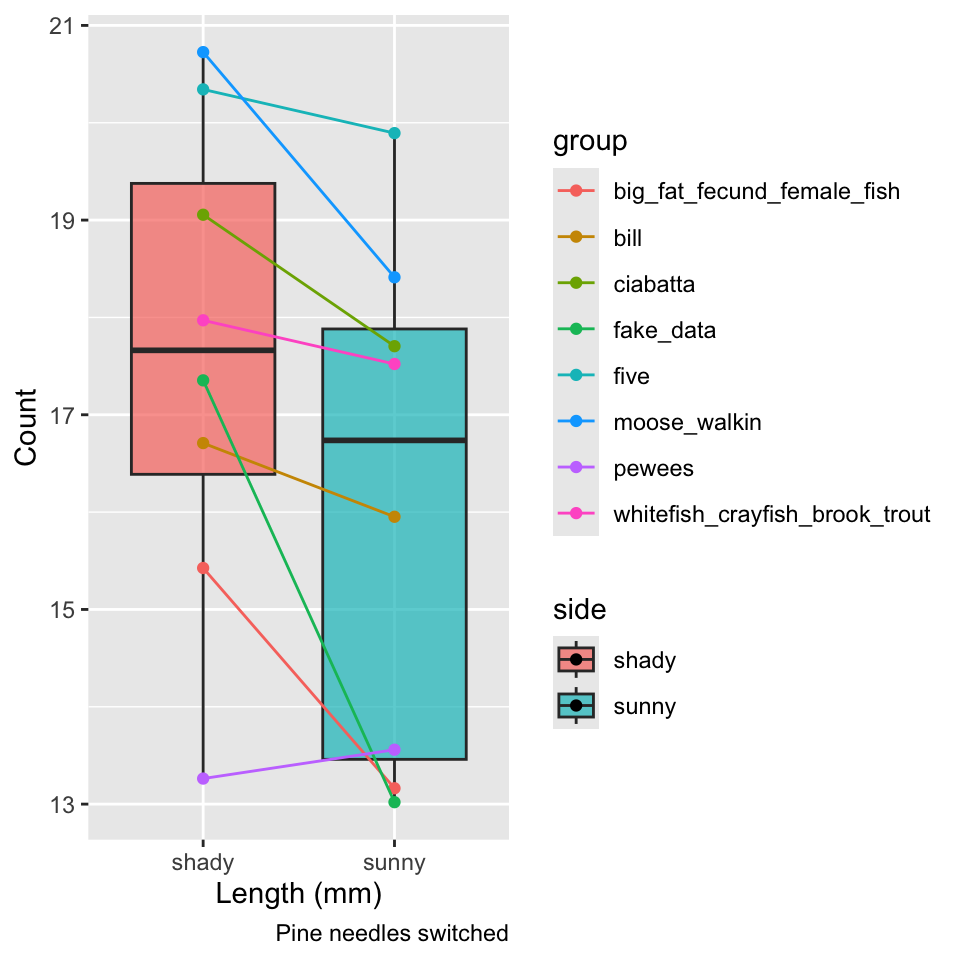

```r
ps_plot
```

# **Lecture 5:** Assumptions of Parametric Tests

**Common assumptions for t-tests:**

1. Normality: Data comes from normally distributed populations
2. Equal variances (for two-sample tests)
3. Independence: Observations are independent
4. No outliers: Extreme values can influence results

What can we do if our data violates these assumptions?

Alternatives when assumptions are violated:

- Data transformation (log, square root, etc.)
- Non-parametric tests
- Robust statistical methods

# **Lecture 5:** Summary and Conclusions

In this activity, we’ve:

1. Formulated hypotheses about pine needle length
2. Tested assumptions for parametric tests
3. Conducted one-sample and two-sample t-tests
4. Visualized data using appropriate methods
5. Learned how to interpret and report t-test results

**Key takeaways:**

- Always check assumptions before conducting tests
- Visualize your data to understand patterns
- Report results comprehensively
- Consider alternatives when assumptions are violated - non parametric tests…

Back to top